# 1README

**PROYECTO FINAL DE BIOINFORMÁTICA**

**Preguntas base para el proyecto**

1. Que tipo de datos quieres usar?
2. En qué formato están los datos?
3. Qué quieres hacer con esos datos?

**Objetivo principal del proyecto**

El obejtivo principal de este proeycto es analizar la filogenia del tiburón blanco *Carcharodon carcharias*. Esta espcie es considerada un especie emblemática de los ecosistemas marinos. Sus longevidades de vida datan de hasta 60 años, y alcanz su madurez recién a los 30 años, haciéndolos una especie de importante connservación.

**¿Cuál es la relevancia de este proyecto?**

Los tiburones en general son considerados controladores biológicos del oceano. Su posición en la cadenada alimenticia como depredadores ápices les otorga este rol biológico. COnservar estas especies de suma importancia, porque ante una inminente existinción, todo el ecosistema mraino se vería afectado. *Carcharodon carcharias* específicamente es considerada una especie vulnerable, seguidos de los tiburones de su misma familia. En este proyecto la importancia de obtener la filogenia de la fmailia Lamnidae, destaca su relevnaica en preservar estas especies. Se han obtenido tan solo 5 especies de está familia,, 1 del género *Carcharodon*, 2 del género *Isurus* y 2 del género *Lamna*, las demás especiesse encuentran extintas.

**Datos sobre el tiburón blanco**

**Datos sobre conservación de los tiburones**

[*Carcharodon carcharias*](https://www.iucnredlist.org/es/species/3855/212629880)

[*Isurus paucus*](https://www.iucnredlist.org/es/species/60225/3095898)

[*Lamna nasus*](https://www.iucnredlist.org/es/species/11200/500969)

[*Lamna ditropis*](https://www.iucnredlist.org/es/species/39342/124402990)

*Carcharodon carcharias*

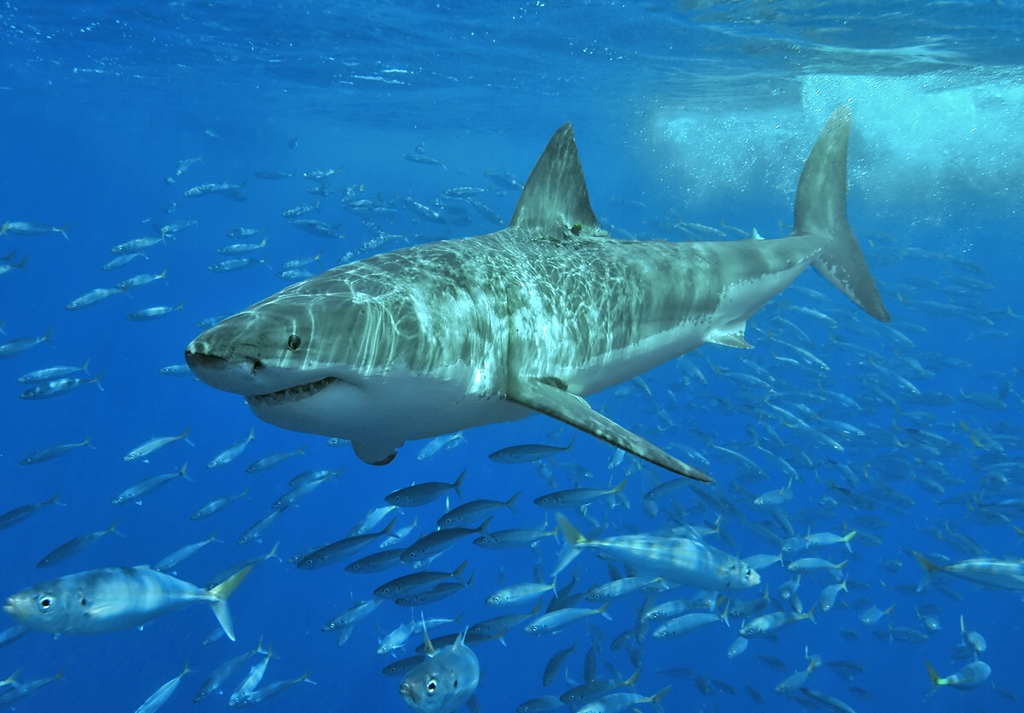

*Isurus oxyrinchus*

[figure not shown]

*Isurus paucus*

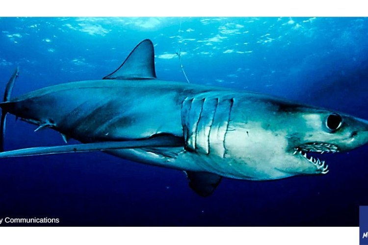

*Lamna nasus*

[figure not shown]

*Lamna ditropis*

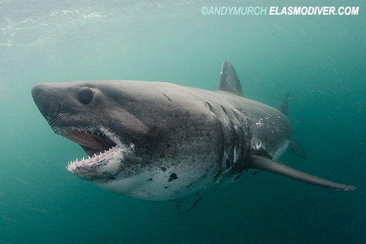

**SECCIÓN 2**

**PEQUEÑA FIOLGENIA DE TOBURONES**

Esta es un pequeña filogenia en la que se muestran las diferentes familias de tiburones

**Figura.1** Filogenia tiburones

[figure not shown]

**Australia. El Gran Tiburón Blanco**

[video not shown]

**¿Por qué son tan importantes los tiburones para el ecosistema?**

[video not shown]